# My Chi Squared Test

William Miller

## Background

A study was done to gather amount of crime found in certain US states. The crimes which were focused on were Murder, Assault, and Rape. The below data table is a subset from that dataset including what was found by other studies to be the top 5 most dangerous states in the united states. The Purpose of this study is to see in these 5 states if the crimes listed are associated with the states. If this is true, then we can predict which crime is most likely to occur in each state.

```r
datatable(dataa1, class = 'cell-border stripe', options = list(pageLength =5, dom = 'tip'))
```

|  | Murder | Assult | UrbanPop | Rape |
| --- | --- | --- | --- | --- |
| Alaska | 10 | 263 | 48 | 44.5 |
| Arkansas | 8.8 | 190 | 50 | 19.5 |
| Louisiana | 15.4 | 249 | 66 | 22.2 |
| New Mexico | 11.4 | 285 | 70 | 32.1 |
| South Carolina | 14.4 | 279 | 48 | 22.5 |

## Hypothesis

$$H_{01}:\ \text{The State and crimes are not associated.}$$
$$H_{a1}:\ \text{The State and crimes are associated.}$$
$$\text{Level of Significance}: \alpha = .05$$
The following tests are used to satisfy the above hypothesis. If the level of significance is over .05 than we can conclude there is sufficient evidence to accept the null, however if this level is not met then we reject the null, and the alternative is true.

## Analysis

### Test

**Chi Squared Test**

```r
ch1 <- chisq.test(dataa1)
pander(ch1)
```

Pearson’s Chi-squared test: `dataa1`

| Test statistic | df | P value |
| --- | --- | --- |
| 21.18 | 12 | 0.04783 * |

### Test Requirements

For us to even consider using the Chi Squared Test there are certain requirements that must be fulfilled. One of those requirements is whether the expectants that result from the Chi Squared Test are greater than $5$. The below charts show us the expectants.

```r
pander(ch1$expected)
```

|  | Murder | Assult | UrbanPop | Rape |
| --- | --- | --- | --- | --- |
| **Alaska** | 12.54 | 264.6 | 58.94 | 29.43 |
| **Arkansas** | 9.205 | 194.2 | 43.26 | 21.6 |
| **Louisiana** | 12.1 | 255.3 | 56.86 | 28.39 |
| **New Mexico** | 13.67 | 288.5 | 64.26 | 32.08 |
| **South Carolina** | 12.49 | 263.4 | 58.68 | 29.3 |

This first chart shows us the actual number of the expectants. As you can see, they are all greater than 5. Since this chart may be harder to read, the one below is provided.

```r
pander(ch1$expected >=5)
```

|  | Murder | Assult | UrbanPop | Rape |
| --- | --- | --- | --- | --- |
| **Alaska** | TRUE | TRUE | TRUE | TRUE |
| **Arkansas** | TRUE | TRUE | TRUE | TRUE |
| **Louisiana** | TRUE | TRUE | TRUE | TRUE |
| **New Mexico** | TRUE | TRUE | TRUE | TRUE |
| **South Carolina** | TRUE | TRUE | TRUE | TRUE |

This chart shows us whether the requirements are met. ‘TRUE’ means that the expectants are greater than $5$, FALSE means that the expectants are less than $5$. From the above chart we can see that TRUE is shown in each category.

## Interesting Information

Knowing that the State and crimes are associated we can then use this chart, which calculates the residuals of the Chi Squared Test to make allocations based on this data.

```r
pander(ch1$residuals)
```

|  | Murder | Assult | UrbanPop | Rape |
| --- | --- | --- | --- | --- |
| **Alaska** | -0.7173 | -0.09803 | -1.425 | 2.779 |
| **Arkansas** | -0.1335 | -0.3035 | 1.024 | -0.4521 |
| **Louisiana** | 0.9495 | -0.3916 | 1.212 | -1.162 |
| **New Mexico** | -0.6145 | -0.2051 | 0.7161 | 0.002794 |
| **South Carolina** | 0.5419 | 0.9589 | -1.394 | -1.256 |

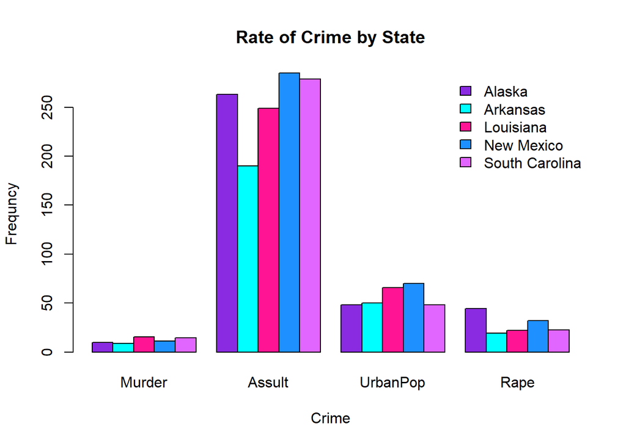

```r
barplot(dataa1, main = "Rate of Crime by State", ylab = "Frequncy", xlab = "Crime", beside = TRUE, col = c("blueviolet", "cyan1", "deeppink", "dodgerblue1", "mediumorchid1"), legend.text = TRUE, args.legend = list(x = "topright", bty = "n"))
```